# mlr starter

May Shen, Research Data Scientist, Axialhealthcare

2019-02-14

# SUMMARY

A brief walk-through of mlr functions that are necessary for basic model tunning.

# mlr vs caret

1. mlr has more possibilities to create different types of tasks: Classification, Regression, Survival, Clustering, Multilabel, Cost-sensitive, Imbalanced data, Functional data, Spatial data. caret only seems to have possibilities for Classification, Regression and Cost-sensitive.
2. mlr has 71 metrics which are easy to choose from, more complicated to change metrics in caret.
3. mlr supports more tuning methods such as F-Racing and model-based optimization, while caret supports only random and grid search.
4. mlr is more compatible for parallelization.

# Preprocessing

**Goal:**

1. Load data
2. Quick preprocessing

```r
data(BreastCancer, package = 'mlbench')
df <- BreastCancer
```

```r
str(df)
```

```
## 'data.frame':    699 obs. of  11 variables:
##  $ Id             : chr  "1000025" "1002945" "1015425" "1016277" ...
##  $ Cl.thickness   : Ord.factor w/ 10 levels "1"<"2"<"3"<"4"<..: 5 5 3 6 4 8 1 2 2 4 ...
##  $ Cell.size      : Ord.factor w/ 10 levels "1"<"2"<"3"<"4"<..: 1 4 1 8 1 10 1 1 1 2 ...
##  $ Cell.shape     : Ord.factor w/ 10 levels "1"<"2"<"3"<"4"<..: 1 4 1 8 1 10 1 2 1 1 ...
##  $ Marg.adhesion  : Ord.factor w/ 10 levels "1"<"2"<"3"<"4"<..: 1 5 1 1 3 8 1 1 1 1 ...
##  $ Epith.c.size   : Ord.factor w/ 10 levels "1"<"2"<"3"<"4"<..: 2 7 2 3 2 7 2 2 2 2 ...
##  $ Bare.nuclei    : Factor w/ 10 levels "1","2","3","4",..: 1 10 2 4 1 10 10 1 1 1 ...
##  $ Bl.cromatin    : Factor w/ 10 levels "1","2","3","4",..: 3 3 3 3 3 9 3 3 1 2 ...
##  $ Normal.nucleoli: Factor w/ 10 levels "1","2","3","4",..: 1 2 1 7 1 7 1 1 1 1 ...
##  $ Mitoses        : Factor w/ 9 levels "1","2","3","4",..: 1 1 1 1 1 1 1 1 5 1 ...
##  $ Class          : Factor w/ 2 levels "benign","malignant": 1 1 1 1 1 2 1 1 1 1 ...
```

```r
summary(df)
```

```
##       Id             Cl.thickness   Cell.size     Cell.shape
##  Length:699         1      :145   1      :384   1      :353
##  Class :character   5      :130   10     : 67   2      : 59
##  Mode  :character   3      :108   3      : 52   10     : 58
##                     4      : 80   2      : 45   3      : 56
##                     10     : 69   4      : 40   4      : 44
##                     2      : 50   5      : 30   5      : 34
##                     (Other):117   (Other): 81   (Other): 95
##  Marg.adhesion  Epith.c.size  Bare.nuclei   Bl.cromatin  Normal.nucleoli
##  1      :407   2      :386   1      :402   2      :166   1      :443
##  2      : 58   3      : 72   10     :132   3      :165   10     : 61
##  3      : 58   4      : 48   2      : 30   1      :152   3      : 44
##  10     : 55   1      : 47   5      : 30   7      : 73   2      : 36
##  4      : 33   6      : 41   3      : 28   4      : 40   8      : 24
##  8      : 25   5      : 39   (Other): 61   5      : 34   6      : 22
##  (Other): 63   (Other): 66   NA's   : 16   (Other): 69   (Other): 69
##     Mitoses          Class
##  1      :579   benign   :458
##  2      : 35   malignant:241
##  3      : 33
##  10     : 14
##  4      : 12
##  7      :  9
##  (Other): 17
```

```r
df$Id = NULL
new_col <- as.numeric(df$Bare.nuclei)
new_col[is.na(new_col)] <- 5.5
new_col <- factor(new_col, levels = c("1", "2", "3", "4", "5", "5.5", "6", "7", "8", "9", "10"), ordered = T)
table(new_col)
```

```
## new_col
##   1   2   3   4   5 5.5   6   7   8   9  10
## 402  30  28  19  30  16   4   8  21   9 132
```

```r
df$Bare.nuclei <- new_col
```

Other options:  
1. createDummyFeatures  
2. normalizeFeatures (center, scale, standardize, range)  
3. mergeSmallFactorLevels  
4. capLargeValues, dropFeatures, removeConstantFeatures, summarizeLevels  
5. …

# Tasks

**Goal:**

1. Set data (data)
2. Set target (target)
3. Set task ID (id)

```r
bc_task = makeClassifTask(data = df, target = 'Class')
bc_task
```

```
## Supervised task: df
## Type: classif
## Target: Class
## Observations: 699
## Features:
## numerics  factors  ordered
##        0        3        6
## Missings: FALSE
## Has weights: FALSE
## Has blocking: FALSE
## Classes: 2
##    benign malignant
##       458       241
## Positive class: benign
```

```r
bc_task = makeClassifTask(id = 'breast cancer classification',
                          data = df, target = 'Class',
                          positive = "malignant")
```

Notes:

1. For classification the target column has to be a factor.
2. makeClassifTask() by default selects the first factor level of the target variable as the positive class. When necessary, use the *positive* argument to modify.

Other tasks:

- RegrTask() for regression problems
- ClassifTask() for binary and multi-class classification problems with class-dependent costs can be handled as well)
- SurvTask() for survival analysis
- ClusterTask() for cluster analysis
- MultilabelTask() for multilabel classification problems
- CostSensTask() for general cost sensitive classification (with example-specific costs)

# Learners

**Goal:**

1. Set package and method (class of learner, cl argument)
2. Set prediction output type (predict.type)
3. Set hyperparameters (par.vals)
4. Set learner ID (id)

```r
bc_learner = makeLearner(cl = "classif.ranger",  # class of learner
                         predict.type = "prob", # prediction output type
                         par.vals = list(), # set hyperparameters
                         predict.threshold = NULL, # threshold for prediction
                         fix.factors.prediction = TRUE) # add a factor level for missing data in test
bc_learner
```

```
## Learner classif.ranger from package ranger
## Type: classif
## Name: Random Forests; Short name: ranger
## Class: classif.ranger
## Properties: twoclass,multiclass,prob,numerics,factors,ordered,featimp,weights,oobpreds
## Predict-Type: prob
## Hyperparameters: num.threads=1,verbose=FALSE,respect.unordered.factors=TRUE
```

To see available learners for the particular task:

```r
learners <- listLearners(bc_task, properties = 'prob', check.packages = FALSE)
head(learners[,c('class', 'package')])
```

| class | package |
| --- | --- |
| classif.cforest | party |
| classif.ctree | party |
| classif.evtree | evtree |
| classif.featureless | mlr |
| classif.penalized.lasso | penalized |
| classif.penalized.ridge | penalized |

A handy function to examine the available hyperparameters is to use the getParamSet function:

```r
getParamSet(bc_learner)
```

```
##                                       Type  len   Def
## num.trees                          integer    -   500
## mtry                               integer    -     -
## min.node.size                      integer    -     -
## replace                            logical    -  TRUE
## sample.fraction                    numeric    -     -
## split.select.weights         numericvector <NA>     -
## always.split.variables             untyped    -     -
## respect.unordered.factors          logical    - FALSE
## importance                        discrete    -  none
## write.forest                       logical    -  TRUE
## scale.permutation.importance       logical    - FALSE
## num.threads                        integer    -     -
## save.memory                        logical    - FALSE
## verbose                            logical    -  TRUE
## seed                               integer    -     -
## keep.inbag                         logical    - FALSE
##                                                 Constr Req Tunable Trafo
## num.trees                                     1 to Inf   -    TRUE     -
## mtry                                          1 to Inf   -    TRUE     -
## min.node.size                                 1 to Inf   -    TRUE     -
## replace                                              -   -    TRUE     -
## sample.fraction                                 0 to 1   -    TRUE     -
## split.select.weights                            0 to 1   -    TRUE     -
## always.split.variables                               -   -    TRUE     -
## respect.unordered.factors                            -   -    TRUE     -
## importance                   none,impurity,permutation   -   FALSE     -
## write.forest                                         -   -   FALSE     -
## scale.permutation.importance                         -   Y   FALSE     -
## num.threads                                   1 to Inf   -   FALSE     -
## save.memory                                          -   -   FALSE     -
## verbose                                              -   -   FALSE     -
## seed                                       -Inf to Inf   -   FALSE     -
## keep.inbag                                           -   -   FALSE     -
```

**List of properties:**

- *numerics*: The method can cope with numerical predictors
- *factors*: The method can cope with factor predictors
- *ordered*: The method can cope with ordered factor predictors
- *NAs*: The method can deal with missing values in a meaningful way (other than simply removing observations with missing values)
- *weights*: The method support observation weights
- *prob*: The method can predict probabilities
- *oneclass, twoclass, multiclass*: One-class, two-class (binary) or multi-class classification problems be handled
- *class.weights*: Class weights can be handled
- *featimp*: The method can return feature importance
- *oobpreds*: The method can make out-of-bag predictions

**Integrated learners:**  
see [link](https://mlr.mlr-org.com/articles/tutorial/integrated_learners.html)

# Train

**Goal:**

1. Set learner
2. Set task
3. Set subset of data
4. Set observation weights

```r
bc_model <- train(learner = bc_learner,
                  task = bc_task)
bc_model
```

```
## Model for learner.id=classif.ranger; learner.class=classif.ranger
## Trained on: task.id = breast cancer classification; obs = 699; features = 9
## Hyperparameters: num.threads=1,verbose=FALSE,respect.unordered.factors=TRUE
```

If the default setting of the learner is okay, you can skip makeLearner() and just start to train the model.

```r
bc_model_default <- train(learner = 'classif.ranger',
                          task = bc_task)
bc_model_default
```

```
## Model for learner.id=classif.ranger; learner.class=classif.ranger
## Trained on: task.id = breast cancer classification; obs = 699; features = 9
## Hyperparameters: num.threads=1,verbose=FALSE,respect.unordered.factors=TRUE
```

To train only a subset, use the *subset* argument.

```r
n <- nrow(df)
in_train <- sample.int(n, round(0.8*n))
in_test <- setdiff(1:n, in_train)
bc_model <- train(learner = bc_learner,
                  task = bc_task,
                  subset = in_train)
```

To assign weight to observations if supported by learner. Use cases:  
1. reduce the influence of outliers 2. increase the influence of certain data, e.g. more recent data 3. incorporate misclassification costs 4. account for class imbalance, give both classes equal importance

```r
target <- df$Class[in_train]
tab <- as.numeric(table(target))
w <- 1/tab[target]
bc_model <- train(learner = bc_learner,
                  task = bc_task,
                  subset = in_train,
                  weights = w)
```

# Predict

**Goal:**

1. make predictions
2. adjust threshold
3. visualize the prediction

To make a prediction:

```r
bc_pred <- predict(object = bc_model,
                   task = bc_task,
                   subset = in_test)
bc_pred
```

```
## Prediction: 140 observations
## predict.type: prob
## threshold: benign=0.50,malignant=0.50
## time: 0.04
##    id     truth prob.benign prob.malignant  response
## 3   3    benign 0.999333333   0.0006666667    benign
## 4   4    benign 0.086814286   0.9131857143 malignant
## 6   6 malignant 0.003574603   0.9964253968 malignant
## 12 12    benign 1.000000000   0.0000000000    benign
## 14 14    benign 0.990599206   0.0094007937    benign
## 18 18    benign 1.000000000   0.0000000000    benign
## ... (140 rows, 5 cols)
```

To adjust threshold:

```r
bc_pred_2 <- setThreshold(pred = bc_pred, threshold = 0.8)
```

To visualize the prediction:

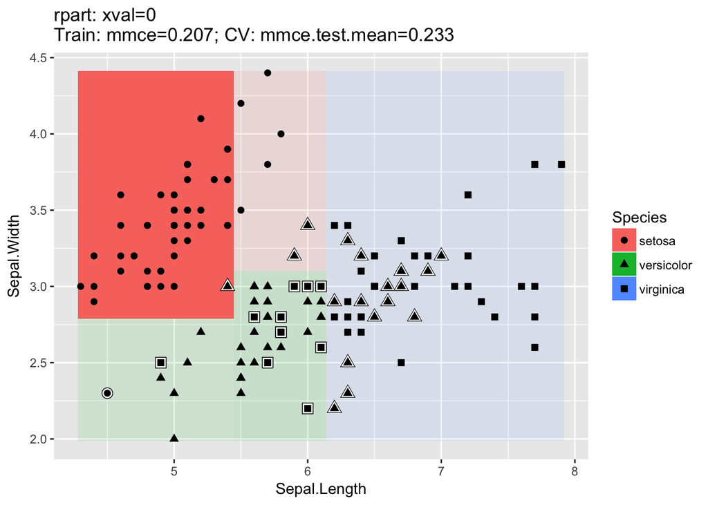

```r
# plotLearnerPrediction(learner = bc_learner, task = bc_task,
#                       features = c('Cell.shape', 'Marg.adhesion'))
lrn = makeLearner("classif.rpart", id = "CART")
plotLearnerPrediction(lrn, task = iris.task)
```

Figure note: The type of symbol shows the true class labels of the data points. Symbols with white border indicate misclassified observations. The posterior probabilities (if the learner under consideration supports this) are represented by the background color where higher saturation means larger probabilities.

Handy functions:  
1. getPredictionTruth( bc_pred )  
2. getPredictionResponse( bc_pred )  
3. getPredictionSE() for standard errors of regression predictions  
4. getPredictionProbabilities( bc_pred )  
5. calculateConfusionMatrix()

# Performance

**Goal:**

1. access performance measures
2. plot performance

To access performance measures:

```r
## list measures
listMeasures("classif", properties = "classif.multi")
```

```
##  [1] "kappa"            "multiclass.brier" "multiclass.aunp"
##  [4] "multiclass.aunu"  "qsr"              "ber"
##  [7] "logloss"          "wkappa"           "timeboth"
## [10] "timepredict"      "acc"              "lsr"
## [13] "featperc"         "multiclass.au1p"  "multiclass.au1u"
## [16] "ssr"              "timetrain"        "mmce"
```

Task-specific measures:

```r
listMeasures(bc_task)
```

```
##  [1] "kappa"            "multiclass.brier" "fn"
##  [4] "fp"               "multiclass.aunp"  "brier.scaled"
##  [7] "multiclass.aunu"  "bac"              "qsr"
## [10] "brier"            "tnr"              "fdr"
## [13] "gmean"            "auc"              "tpr"
## [16] "ber"              "logloss"          "ppv"
## [19] "wkappa"           "mcc"              "timeboth"
## [22] "timepredict"      "acc"              "lsr"
## [25] "featperc"         "multiclass.au1p"  "multiclass.au1u"
## [28] "gpr"              "tn"               "tp"
## [31] "ssr"              "fnr"              "f1"
## [34] "fpr"              "npv"              "timetrain"
## [37] "mmce"
```

To access performance measures:

```r
performance(pred = bc_pred, measures = list(f1, fpr, auc, acc))
```

```
##         f1        fpr        auc        acc
## 0.96000000 0.03296703 0.98609554 0.97142857
```

To plot performance vs threshold:

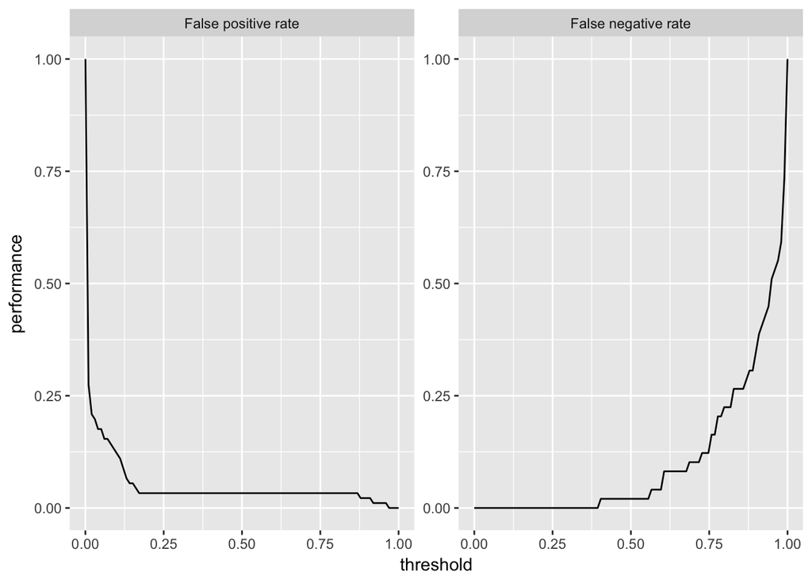

```r
d <- generateThreshVsPerfData(bc_pred, measures = list(fpr, fnr))
plotThreshVsPerf(d)
```

# Resampling

**Goal:**

1. set resampling strategy, e.g., cross-validation, holdout
2. set resampling instance

To set resampling:

```r
# create resampling strategy, note that cv5 is pre-defined in mlr as well
cv5 <- makeResampleDesc(method = 'CV', iters = 5, stratify = T)
bc_cv5 <- resample(learner = bc_learner,
                   task = bc_task,
                   resampling = cv5,
                   measures = auc,
                   models = T) # to keep the model
```

```
## [Resample] cross-validation iter 1: auc.test.mean=0.995
## [Resample] cross-validation iter 2: auc.test.mean=0.997
## [Resample] cross-validation iter 3: auc.test.mean=0.989
## [Resample] cross-validation iter 4: auc.test.mean=0.99
## [Resample] cross-validation iter 5: auc.test.mean=0.99
## [Resample] Aggr. Result: auc.test.mean=0.993
```

To access the resampling results:

```r
bc_cv5$aggr
```

```
## auc.test.mean
##     0.9925057
```

```r
bc_cv5$measures.test
```

| iter | auc |
| --- | --- |
| 1 | 0.9954212 |
| 2 | 0.9972527 |
| 3 | 0.9893569 |
| 4 | 0.9904614 |
| 5 | 0.9900362 |

To set resampling instance:

```r
bc_cv5_in <- makeResampleInstance(desc = cv5, task = bc_task)
```

Resample instances make it easy to reproduce model results and to compare models. We can run different models on the same resampling instance with the same split of the data, which is more fair than comparisons across different splits of the data.

# Tuning

**Goal:**

1. tune hyperparameters

**Steps:**

First, set the search space:

```r
bc_params <- makeParamSet(
  makeIntegerParam('num.trees', lower = 100, upper = 1000),
  makeIntegerParam('mtry', lower = 1, upper = 9)
)
```

More options:

- makeNumericParam(“u”, lower=1)
- makeIntegerParam(“v”, lower=1, upper=2)
- makeDiscreteParam(“w”, values=1:2)
- makeLogicalParam(“x”)
- makeDiscreteVectorParam(“y”, len=2, values=c(“a”, “b”))

Second, select the optimization algorithm:

```r
bc_control = makeTuneControlRandom(maxit = 10L)
```

More options:

- makeTuneControlGrid()
- makeTuneControlIrace()

Third, we select the resampling strategy and the performance measure for the tuning. In this case let’s use the pre-defined resampling method cv5.

```r
bc_tune <- tuneParams(learner = bc_learner,
                      task = bc_task,
                      resampling = cv5,
                      par.set = bc_params,
                      control = bc_control,
                      measures = auc)
```

```
## [Tune] Started tuning learner classif.ranger for parameter set:
```

```
##              Type len Def       Constr Req Tunable Trafo
## num.trees integer   -   - 100 to 1e+03   -    TRUE     -
## mtry      integer   -   -       1 to 9   -    TRUE     -
```

```
## With control class: TuneControlRandom
```

```
## Imputation value: -0
```

```
## [Tune-x] 1: num.trees=388; mtry=2
```

```
## [Tune-y] 1: auc.test.mean=0.992; time: 0.0 min
```

```
## [Tune-x] 2: num.trees=359; mtry=6
```

```
## [Tune-y] 2: auc.test.mean=0.989; time: 0.0 min
```

```
## [Tune-x] 3: num.trees=481; mtry=2
```

```
## [Tune-y] 3: auc.test.mean=0.992; time: 0.0 min
```

```
## [Tune-x] 4: num.trees=540; mtry=6
```

```
## [Tune-y] 4: auc.test.mean=0.99; time: 0.0 min
```

```
## [Tune-x] 5: num.trees=528; mtry=5
```

```
## [Tune-y] 5: auc.test.mean=0.991; time: 0.0 min
```

```
## [Tune-x] 6: num.trees=420; mtry=4
```

```
## [Tune-y] 6: auc.test.mean=0.991; time: 0.0 min
```

```
## [Tune-x] 7: num.trees=527; mtry=7
```

```
## [Tune-y] 7: auc.test.mean=0.99; time: 0.0 min
```

```
## [Tune-x] 8: num.trees=347; mtry=8
```

```
## [Tune-y] 8: auc.test.mean=0.989; time: 0.0 min
```

```
## [Tune-x] 9: num.trees=940; mtry=3
```

```
## [Tune-y] 9: auc.test.mean=0.991; time: 0.0 min
```

```
## [Tune-x] 10: num.trees=739; mtry=6
```

```
## [Tune-y] 10: auc.test.mean=0.989; time: 0.0 min
```

```
## [Tune] Result: num.trees=481; mtry=2 : auc.test.mean=0.992
```

To access the tuning results:

```r
# best-performing parameters
bc_tune$x
```

```
## $num.trees
## [1] 481
##
## $mtry
## [1] 2
```

```r
# best performance
bc_tune$y
```

```
## auc.test.mean
##     0.9918146
```

To update the learner with the best parameters:

```r
final_bc_learner <- setHyperPars(learner = bc_learner,
                                 par.vals = bc_tune$x)
final_bc_model <- train(learner = final_bc_learner,
                        task = bc_task)
final_bc_predict <- predict(object = final_bc_model,
                            task = bc_task)
```

To view the tuning effect:

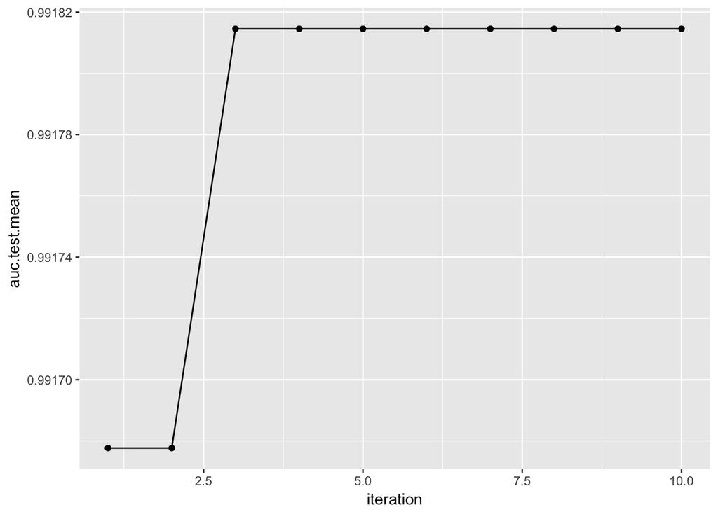

```r
tune_data = generateHyperParsEffectData( tune.result = bc_tune )
plotHyperParsEffect(hyperpars.effect.data = tune_data,
                    x = "iteration", y = "auc.test.mean",
                    plot.type = "line")
```

# Benchmark Experiments

- Parallelization
- Visualization

# Reference

https://mlr.mlr-org.com/index.html [mlr vs. caret](http://philipppro.github.io/2018-11-9-mlr_vs_caret/)